# Raminski_UCB_R_Class_Asgt_9

Michael Raminski

Thursday, May 18, 2017

## Diary

For this assignment I used a database featuring the 2016 fantasy football statistics of the top 50 offensive players at each position.

Data Source: https://fantasydata.com/nfl-stats/nfl-fantasy-football-stats.aspx

With this data set, I addressed assignment item #6d, (clustering models in Kabacoff Capter 16) and tried several methods of hierarchical clustering.

I don’t really unnderstand the Hubert Statistic graphs that are being generated (neither how they are being generated nor what they are telling me).

I’m still having trouble with the par() function, which never seems to work for me. I wasn’t able to set the charts to layout as a single table rather than a side by side presentation (which makes the final cluster chart difficult to read).

## Summary of Results

I chose to run the hierarchical clustering with two methods: Average linkage and Ward. The average linkage method is a compromise between single linkage (which is prone to chaining) and complete linkage (which can be sensitive to outliers). The Ward method is a very common approach that seems to yield more reliable results. In general, it seemed that the Ward method gave me more sensible results. In the cases of QB, RB and TE, the average linkage method would assign one or several unique clusters to a single player; and a lot of those cases were isolating players that aren’t necessarily unique (or at least aren’t stand out performers).

When using the average linkage method, both WR and TE suggested that the ideal number of clusters was only 2. This doesn’t make sense with this data, there should be at least 3 tiers of players at each position. So, in both cases, I used the next most suggested number of clusters which was 3. When using Ward’s method, for both RB and WR, the suggested number of clusters was also just 2. Again, this doesn’t make intuitive sense, so I increased both to 4 (based on the next most suggested number).

Overall, it didn’t seem that either method gave me very sensible results. I would have liked to see more even sized clusters populated by similar performing players. Part of the problem may be that I included too many variables. For each position, I included all variables, even though prior assignments had shown that just a few variables were significant for each position. By doing this, I am giving an even weight to variables that may not be as important as others. I had originally tries using just the significant variables, however, the results did not look reasonable and I don’t believe that clustering is ideal for data sets with a limited number of variables.

## Assignment

#### Split the data into 4 data frames by position, eliminate the players toward the bottom of points scored (as this may lead to skew), and select only the most relevant stats for each position. Then sort descending by Fantasy Points per Game

```r
qb <- select(filter(fantasy, Position=="QB" & Position_Rank <= 25), c(2,23:28,37))
qb <- arrange(qb,desc(Fantasy_PPG))
head(qb)
```

```
##          Player Pass_Attempts_Per_Game Pass_Yards_Per_Game
## 1 Aaron Rodgers               38.12500            276.7500
## 2     Matt Ryan               33.37500            309.0000
## 3     Tom Brady               36.00000            296.1667
## 4    Drew Brees               42.06250            325.5000
## 5   Andrew Luck               36.33333            282.6667
## 6  Kirk Cousins               37.87500            307.3125
##   Pass_TD_Per_Game Pass_TD_Int_Ratio Rush_Yards_Per_Game
## 1         2.500000          5.714286           23.062500
## 2         2.375000          5.428571            7.312500
## 3         2.333333         14.000000            5.333333
## 4         2.312500          2.466667            1.250000
## 5         2.066667          2.384615           22.733333
## 6         1.562500          2.083333            6.000000
##   Rush_Attempts_Per_Game Fantasy_PPG
## 1               4.187500    23.75125
## 2               2.187500    21.71625
## 3               2.333333    21.54667
## 4               1.437500    20.77000
## 5               4.266667    20.51333
## 6               2.125000    18.76750
```

```r
rb <- select(filter(fantasy, Position=="RB" & Position_Rank <= 40), c(2,27:33,37))
rb <- arrange(rb,desc(Fantasy_PPG))
head(rb)
```

```
##            Player Rush_Yards_Per_Game Rush_Attempts_Per_Game
## 1   David Johnson            77.43750               18.31250
## 2    Le'Veon Bell           105.66667               21.75000
## 3 Ezekiel Elliott           101.93750               20.12500
## 4    LeSean McCoy            84.46667               15.60000
## 5   Melvin Gordon            76.69231               19.53846
## 6  DeMarco Murray            80.43750               18.31250
##   Rush_Yards_Per_Attempt Rush_TD_Per_Game Touches_Per_Game
## 1               4.228669        1.0000000         23.31250
## 2               4.858238        0.5833333         28.00000
## 3               5.065217        0.9375000         22.12500
## 4               5.414530        0.8666667         19.00000
## 5               3.925197        0.7692308         22.69231
## 6               4.392491        0.5625000         21.62500
##   Targets_Per_Game Reception_Percent Fantasy_PPG
## 1         7.500000         0.6666667    20.48750
## 2         7.833333         0.7978723    20.20000
## 3         2.500000         0.8000000    18.33750
## 4         3.866667         0.8793103    16.55333
## 5         4.384615         0.7192982    16.12308
## 6         4.187500         0.7910448    15.05000
```

```r
wr <- select(filter(fantasy, Position=="WR" & Position_Rank <= 40), c(2,32:37))
wr <- arrange(wr,desc(Fantasy_PPG))
head(wr)
```

```
##             Player Targets_Per_Game Reception_Percent
## 1    Antonio Brown        10.266667         0.6883117
## 2       Mike Evans        10.812500         0.5549133
## 3     Jordy Nelson         9.500000         0.6381579
## 4      Julio Jones         9.214286         0.6434109
## 5 Odell Beckham Jr        10.562500         0.5976331
## 6         AJ Green        10.000000         0.6600000
##   Reception_TD_Per_Game Yards_Per_Target Yards_Per_Reception Fantasy_PPG
## 1             0.8000000         8.337662            12.11321    13.42000
## 2             0.7500000         7.635838            13.76042    13.00625
## 3             0.8750000         8.269737            12.95876    12.98125
## 4             0.4285714        10.922481            16.97590    12.63571
## 5             0.6250000         8.088757            13.53465    12.22500
## 6             0.4000000         9.640000            14.60606    12.04000
```

```r
te <- select(filter(fantasy, Position=="TE" & Position_Rank <= 25), c(2,32:37))
te <- arrange(te,desc(Fantasy_PPG))
head(te)
```

```
##           Player Targets_Per_Game Reception_Percent Reception_TD_Per_Game
## 1 Rob Gronkowski         4.750000         0.6578947             0.3750000
## 2   Tyler Eifert         5.875000         0.6170213             0.6250000
## 3   Travis Kelce         7.312500         0.7264957             0.2500000
## 4    Jordan Reed         7.416667         0.7415730             0.5000000
## 5 Delanie Walker         6.800000         0.6372549             0.4666667
## 6     Greg Olsen         8.062500         0.6201550             0.1875000
##   Yards_Per_Target Yards_Per_Reception Fantasy_PPG
## 1        14.210526            21.60000    9.000000
## 2         8.382979            13.58621    8.675000
## 3         9.615385            13.23529    8.625000
## 4         7.707865            10.39394    8.550000
## 5         7.843137            12.30769    8.206667
## 6         8.317829            13.41250    7.956250
```

#### Hierarchical Clustering Results by Position (Average Linkage Method)

##### QB

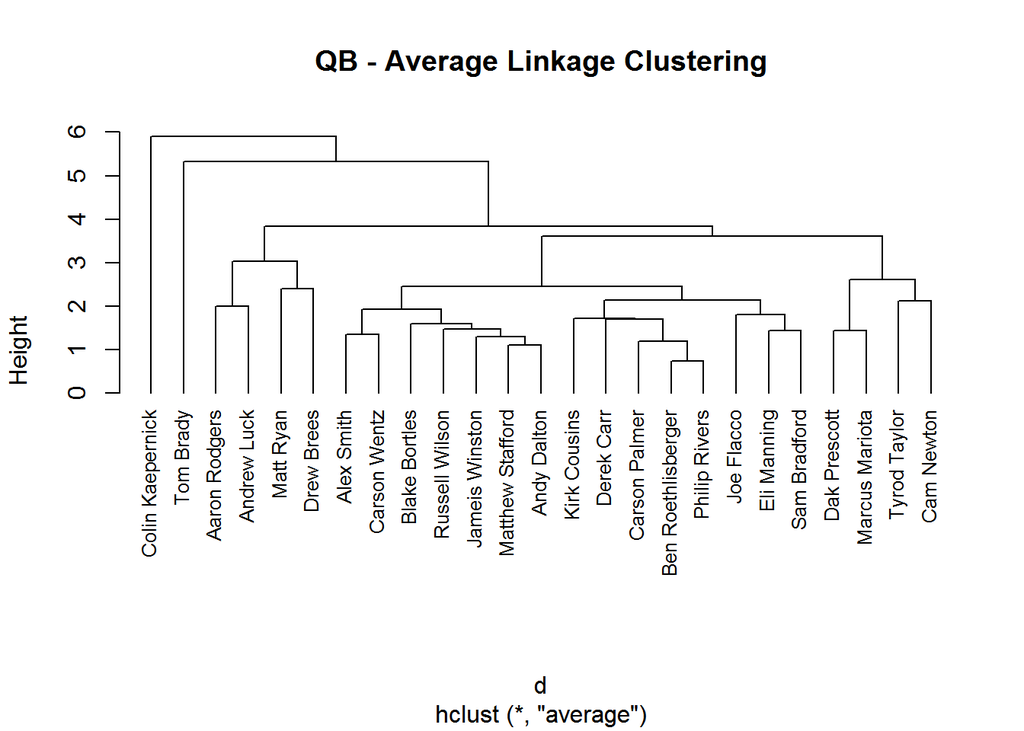

```r
data(qb, package="flexclust")
row.names(qb) <- qb[,1]
qb.scaled <- scale(qb[,-1])
d <- dist(qb.scaled)
fit.average <- hclust(d, method="average")
plot(fit.average, hang=-1, cex=.8, main="QB - Average Linkage Clustering")
```

```r
devAskNewPage(ask=TRUE)
qbnc <- NbClust(qb.scaled, distance="euclidean", min.nc=2, max.nc=15, method="average")
```

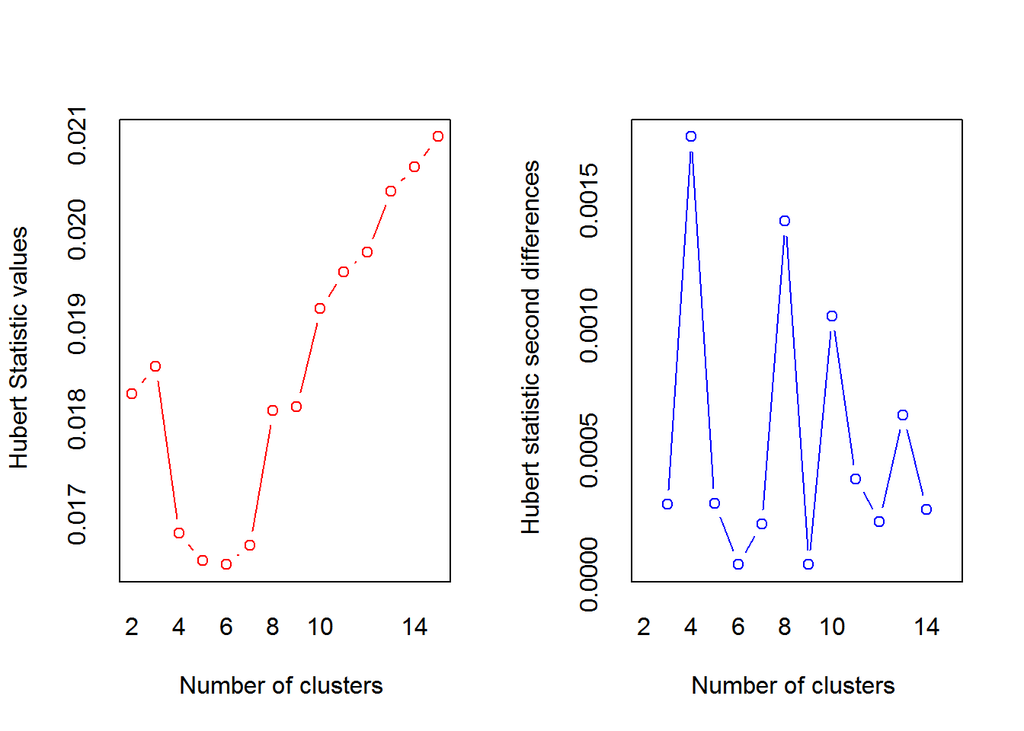

```
## *** : The Hubert index is a graphical method of determining the number of clusters.
##                 In the plot of Hubert index, we seek a significant knee that corresponds to a
##                 significant increase of the value of the measure i.e the significant peak in Hubert
##                 index second differences plot.
##
```

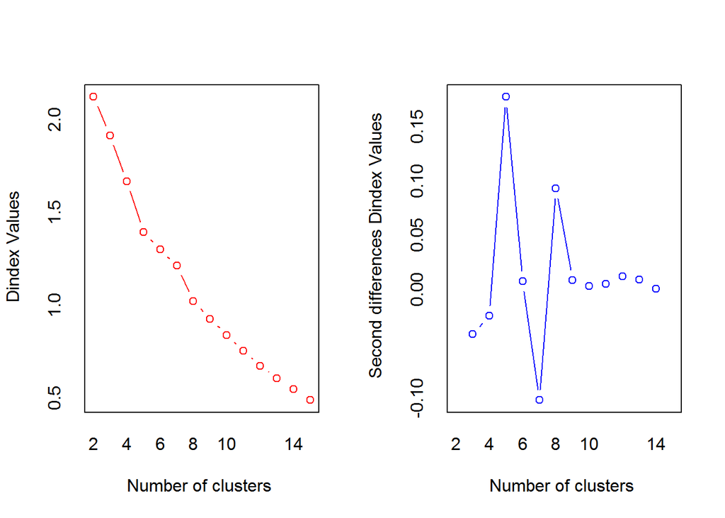

```
## *** : The D index is a graphical method of determining the number of clusters.
##                 In the plot of D index, we seek a significant knee (the significant peak in Dindex
##                 second differences plot) that corresponds to a significant increase of the value of
##                 the measure.
##
## * Among all indices:
## * 5 proposed 2 as the best number of clusters
## * 4 proposed 3 as the best number of clusters
## * 1 proposed 4 as the best number of clusters
## * 6 proposed 5 as the best number of clusters
## * 3 proposed 8 as the best number of clusters
## * 2 proposed 13 as the best number of clusters
## * 3 proposed 15 as the best number of clusters
##
##                    ***** Conclusion *****
##
## * According to the majority rule, the best number of clusters is  5
##
##
```

```r
table(qbnc$Best.n[1,])
```

```
##
##  0  2  3  4  5  8 13 15
##  2  5  4  1  6  3  2  3
```

```r
barplot(table(qbnc$Best.n[1,]),
        xlab="Number of Clusters", ylab="Number of Criteria",
        main="Number of Clusters Chosen")

qbclusters <- cutree(fit.average, k=5)
table(qbclusters)
```

```
## qbclusters
##  1  2  3  4  5
##  4  1 15  4  1
```

```r
aggregate(qb[,-1], by=list(cluster=qbclusters), median)
```

```
##   cluster Pass_Attempts_Per_Game Pass_Yards_Per_Game Pass_TD_Per_Game
## 1       1               37.22917            295.8333         2.343750
## 2       2               36.00000            296.1667         2.333333
## 3       3               37.12500            262.8750         1.500000
## 4       4               29.60000            228.7937         1.352083
## 5       5               20.75000            140.0625         1.000000
##   Pass_TD_Int_Ratio Rush_Yards_Per_Game Rush_Attempts_Per_Game Fantasy_PPG
## 1          3.947619           15.022917               3.187500    21.24312
## 2         14.000000            5.333333               2.333333    21.54667
## 3          1.875000            6.000000               2.312500    16.20800
## 4          2.861111           23.600000               5.000000    17.62967
## 5          4.000000           29.250000               4.312500    12.52750
```

```r
aggregate(as.data.frame(qb.scaled), by=list(cluster=qbclusters),
          median)
```

```
##   cluster Pass_Attempts_Per_Game Pass_Yards_Per_Game Pass_TD_Per_Game
## 1       1              0.4344271           0.9973671        1.5304699
## 2       2              0.1643130           1.0061747        1.5081903
## 3       3              0.4115360           0.1265221       -0.2741794
## 4       4             -1.2421112          -0.7739933       -0.5905500
## 5       5             -3.1869321          -3.1185040       -1.3436012
##   Pass_TD_Int_Ratio Rush_Yards_Per_Game Rush_Attempts_Per_Game Fantasy_PPG
## 1         0.2993100           0.2648327              0.1826213   1.4230641
## 2         4.0736259          -0.6707110             -0.3840228   1.5329301
## 3        -0.4788856          -0.6063433             -0.3978434  -0.3993831
## 4        -0.1086356           1.0929628              1.3850124   0.1151846
## 5         0.3189772           1.6384787              0.9289330  -1.7315282
```

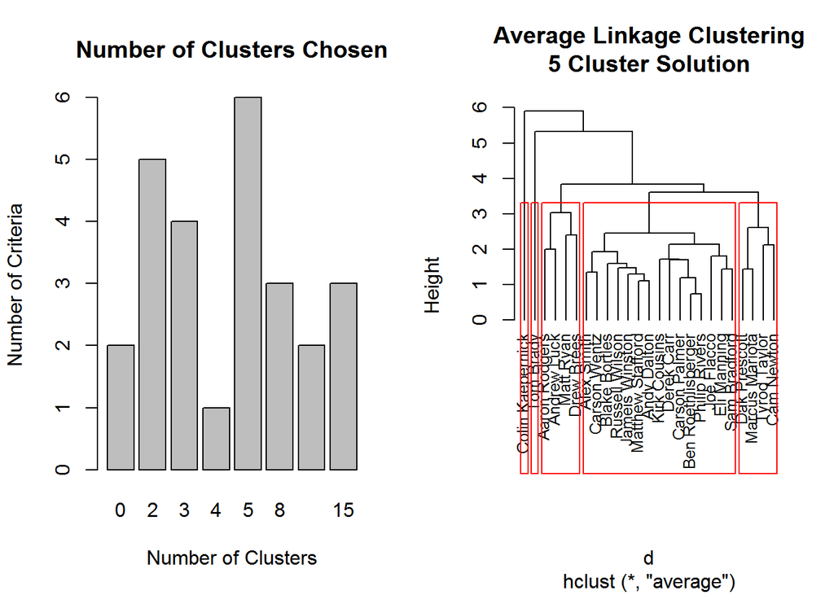

```r
plot(fit.average, hang=-1, cex=.8,
     main="Average Linkage Clustering\n5 Cluster Solution")
rect.hclust(fit.average, k=5)
```

##### RB

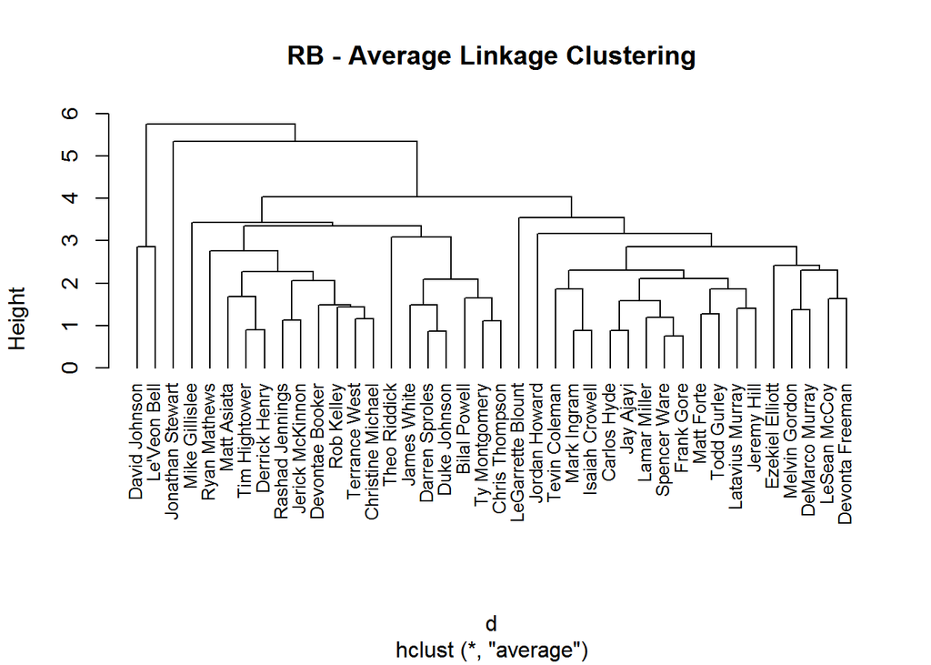

```r
data(rb, package="flexclust")
row.names(rb) <- rb[,1]
rb.scaled <- scale(rb[,-1])
d <- dist(rb.scaled)
fit.average <- hclust(d, method="average")
plot(fit.average, hang=-1, cex=.8, main="RB - Average Linkage Clustering")
```

```r
devAskNewPage(ask=TRUE)
rbnc <- NbClust(rb.scaled, distance="euclidean", min.nc=2, max.nc=15, method="average")
```

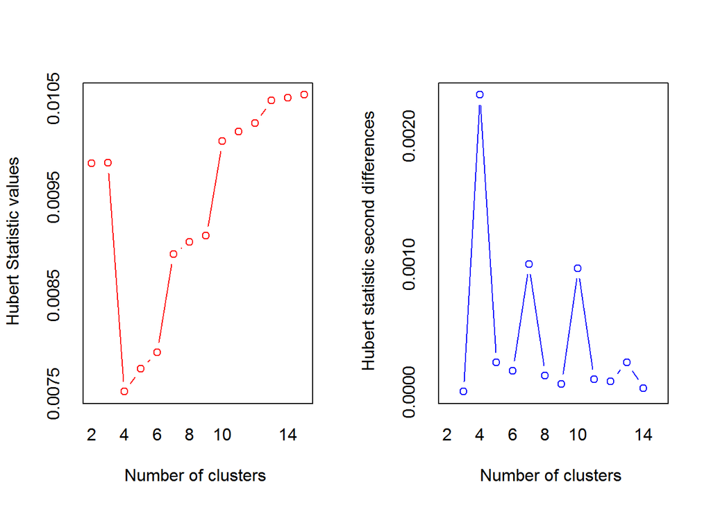

```
## *** : The Hubert index is a graphical method of determining the number of clusters.
##                 In the plot of Hubert index, we seek a significant knee that corresponds to a
##                 significant increase of the value of the measure i.e the significant peak in Hubert
##                 index second differences plot.
##
```

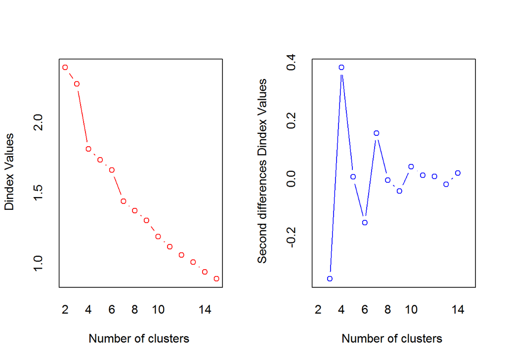

```
## *** : The D index is a graphical method of determining the number of clusters.
##                 In the plot of D index, we seek a significant knee (the significant peak in Dindex
##                 second differences plot) that corresponds to a significant increase of the value of
##                 the measure.
##
## * Among all indices:
## * 4 proposed 2 as the best number of clusters
## * 4 proposed 3 as the best number of clusters
## * 9 proposed 4 as the best number of clusters
## * 1 proposed 7 as the best number of clusters
## * 1 proposed 10 as the best number of clusters
## * 1 proposed 14 as the best number of clusters
## * 4 proposed 15 as the best number of clusters
##
##                    ***** Conclusion *****
##
## * According to the majority rule, the best number of clusters is  4
##
##
```

```r
table(rbnc$Best.n[1,])
```

```
##
##  0  2  3  4  7 10 14 15
##  2  4  4  9  1  1  1  4
```

```r
barplot(table(rbnc$Best.n[1,]),
        xlab="Number of Clusters", ylab="Number of Criteria",
        main="Number of Clusters Chosen")

rbclusters <- cutree(fit.average, k=4)
table(rbclusters)
```

```
## rbclusters
##  1  2  3  4
##  2 19 18  1
```

```r
aggregate(rb[,-1], by=list(cluster=rbclusters), median)
```

```
##   cluster Rush_Yards_Per_Game Rush_Attempts_Per_Game
## 1       1            91.55208               20.03125
## 2       2            67.43750               15.75000
## 3       3            35.81667                8.25000
## 4       4            63.38462               16.76923
##   Rush_Yards_Per_Attempt Rush_TD_Per_Game Touches_Per_Game
## 1               4.543453        0.7916667         25.65625
## 2               4.392491        0.5333333         18.76923
## 3               4.223443        0.2403846         10.49167
## 4               3.779817        0.6923077         17.38462
##   Targets_Per_Game Reception_Percent Fantasy_PPG
## 1         7.666667         0.7322695   20.343750
## 2         3.071429         0.7857143   12.514286
## 3         3.052885         0.7880184    7.196667
## 4         1.615385         0.3809524   10.646154
```

```r
aggregate(as.data.frame(rb.scaled), by=list(cluster=rbclusters),
          median)
```

```
##   cluster Rush_Yards_Per_Game Rush_Attempts_Per_Game
## 1       1           1.6142279              1.4565310
## 2       2           0.5524804              0.6026518
## 3       3          -0.8397617             -0.8931950
## 4       4           0.3740349              0.8059336
##   Rush_Yards_Per_Attempt Rush_TD_Per_Game Touches_Per_Game
## 1             0.25323247        1.2729185        1.9925647
## 2             0.03361106        0.3174114        0.6778408
## 3            -0.21232281       -0.7661289       -0.9023366
## 4            -0.85771746        0.9054158        0.4135193
##   Targets_Per_Game Reception_Percent Fantasy_PPG
## 1        2.6590251        -0.3870162  2.44582784
## 2       -0.1181445         0.1980318  0.45013757
## 3       -0.1293517         0.2232548 -0.90529624
## 4       -0.9981166        -4.2328058 -0.02603966
```

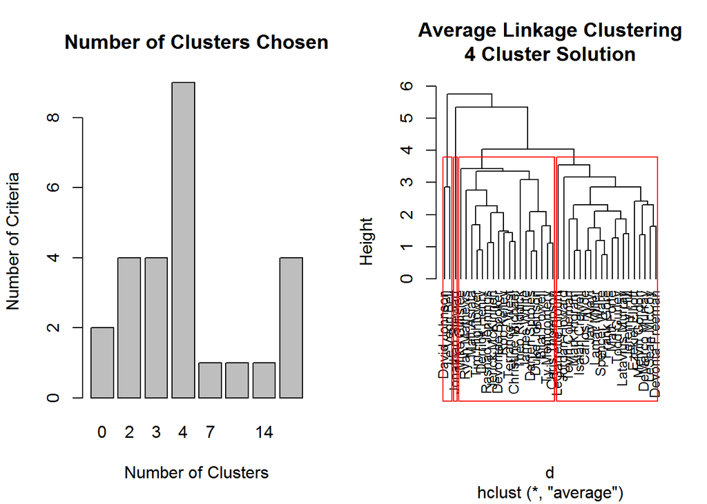

```r
plot(fit.average, hang=-1, cex=.8,
     main="Average Linkage Clustering\n4 Cluster Solution")
rect.hclust(fit.average, k=4)
```

##### WR

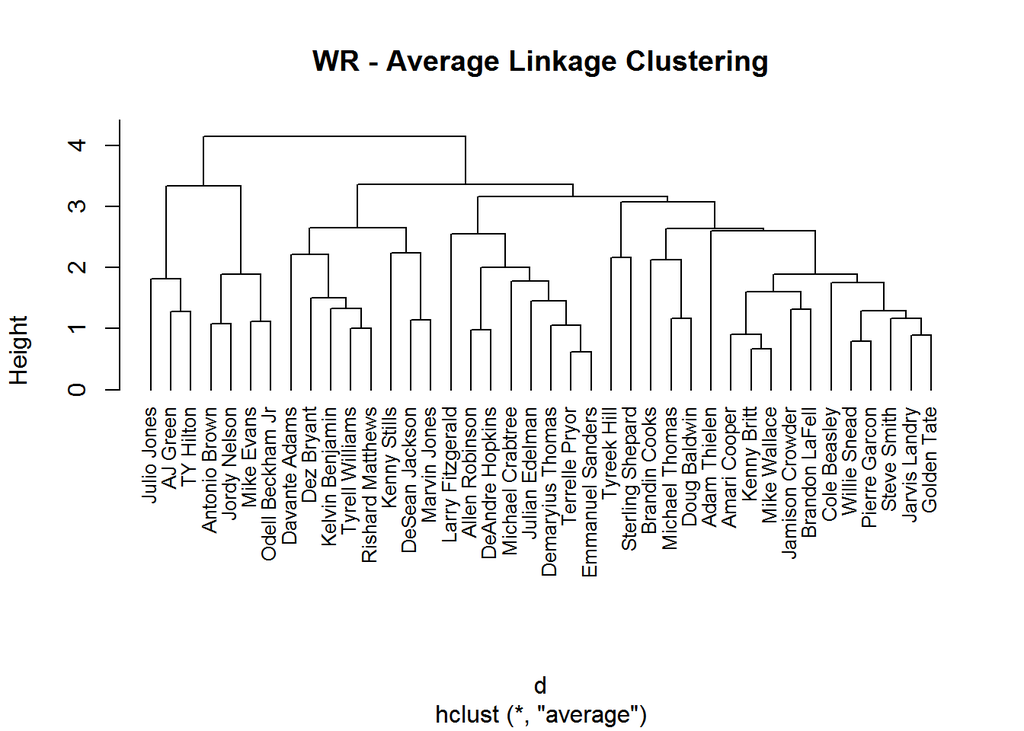

```r
data(wr, package="flexclust")
row.names(wr) <- wr[,1]
wr.scaled <- scale(wr[,-1])
d <- dist(wr.scaled)
fit.average <- hclust(d, method="average")
plot(fit.average, hang=-1, cex=.8, main="WR - Average Linkage Clustering")
```

```r
devAskNewPage(ask=TRUE)
wrnc <- NbClust(wr.scaled, distance="euclidean", min.nc=2, max.nc=15, method="average")
```

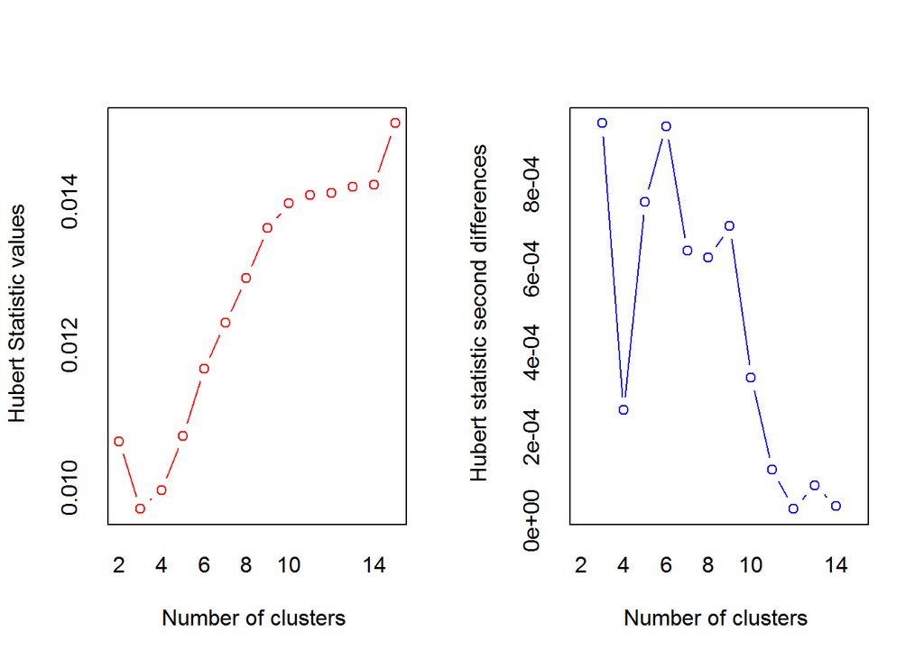

```
## *** : The Hubert index is a graphical method of determining the number of clusters.
##                 In the plot of Hubert index, we seek a significant knee that corresponds to a
##                 significant increase of the value of the measure i.e the significant peak in Hubert
##                 index second differences plot.
##
```

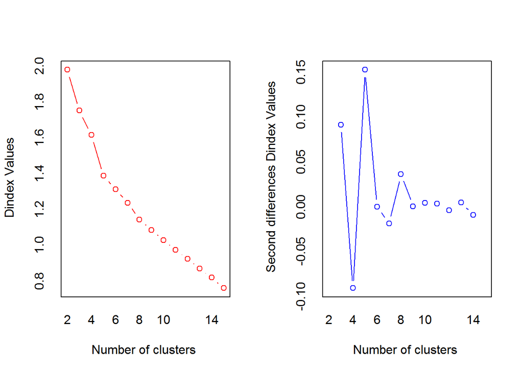

```
## *** : The D index is a graphical method of determining the number of clusters.
##                 In the plot of D index, we seek a significant knee (the significant peak in Dindex
##                 second differences plot) that corresponds to a significant increase of the value of
##                 the measure.
##
## * Among all indices:
## * 6 proposed 2 as the best number of clusters
## * 5 proposed 3 as the best number of clusters
## * 2 proposed 4 as the best number of clusters
## * 4 proposed 5 as the best number of clusters
## * 1 proposed 6 as the best number of clusters
## * 1 proposed 8 as the best number of clusters
## * 1 proposed 10 as the best number of clusters
## * 1 proposed 13 as the best number of clusters
## * 1 proposed 14 as the best number of clusters
## * 2 proposed 15 as the best number of clusters
##
##                    ***** Conclusion *****
##
## * According to the majority rule, the best number of clusters is  2
##
##
```

```r
table(wrnc$Best.n[1,])
```

```
##
##  0  2  3  4  5  6  8 10 13 14 15
##  2  6  5  2  4  1  1  1  1  1  2
```

```r
barplot(table(wrnc$Best.n[1,]),
        xlab="Number of Clusters", ylab="Number of Criteria",
        main="Number of Clusters Chosen")

wrclusters <- cutree(fit.average, k=3)
table(wrclusters)
```

```
## wrclusters
##  1  2  3
##  7 25  8
```

```r
aggregate(wr[,-1], by=list(cluster=wrclusters), median)
```

```
##   cluster Targets_Per_Game Reception_Percent Reception_TD_Per_Game
## 1       1        10.000000         0.6381579                0.6250
## 2       2         7.812500         0.6666667                0.3125
## 3       3         7.120833         0.5469903                0.5000
##   Yards_Per_Target Yards_Per_Reception Fantasy_PPG
## 1         8.337662            13.76042    12.63571
## 2         8.056075            12.23077     8.26875
## 3         8.824580            15.63391     8.76875
```

```r
aggregate(as.data.frame(wr.scaled), by=list(cluster=wrclusters),
          median)
```

```
##   cluster Targets_Per_Game Reception_Percent Reception_TD_Per_Game
## 1       1        1.3672063         0.1140375             1.2000793
## 2       2       -0.1122380         0.4959710            -0.6230694
## 3       3       -0.5800242        -1.1073396             0.4708198
##   Yards_Per_Target Yards_Per_Reception Fantasy_PPG
## 1      -0.01360602           0.1868306   1.8949032
## 2      -0.26336240          -0.5708075  -0.5628949
## 3       0.41826939           1.1147779  -0.2814868
```

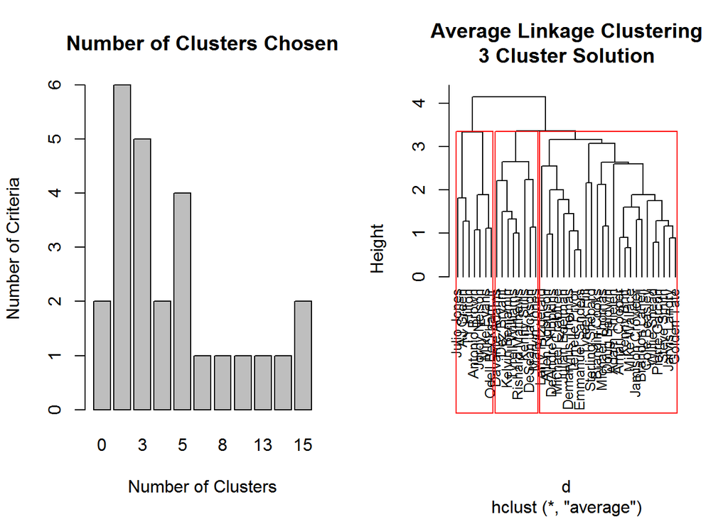

```r
plot(fit.average, hang=-1, cex=.8,
     main="Average Linkage Clustering\n3 Cluster Solution")
rect.hclust(fit.average, k=3)
```

##### TE

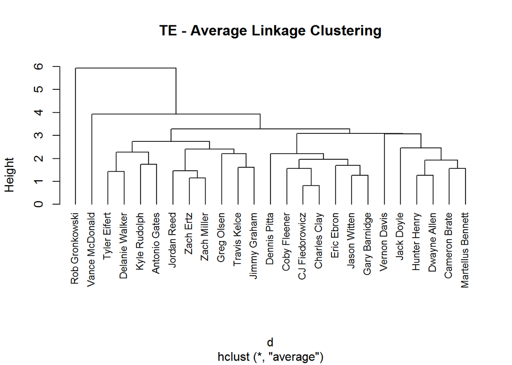

```r
data(te, package="flexclust")
row.names(te) <- te[,1]
te.scaled <- scale(te[,-1])
d <- dist(te.scaled)
fit.average <- hclust(d, method="average")
plot(fit.average, hang=-1, cex=.8, main="TE - Average Linkage Clustering")
```

```r
devAskNewPage(ask=TRUE)
tenc <- NbClust(te.scaled, distance="euclidean", min.nc=2, max.nc=15, method="average")
```

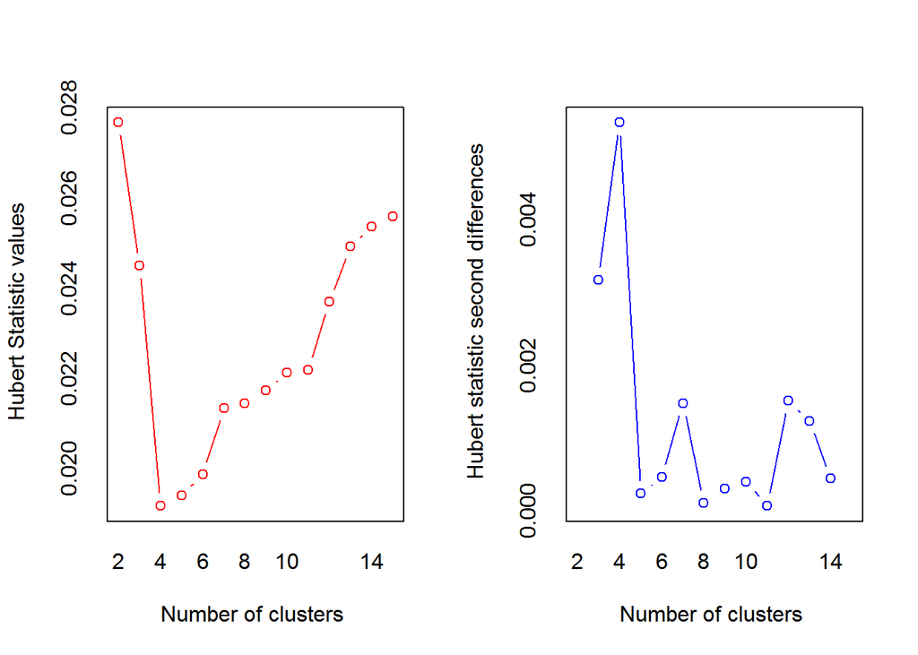

```
## *** : The Hubert index is a graphical method of determining the number of clusters.
##                 In the plot of Hubert index, we seek a significant knee that corresponds to a
##                 significant increase of the value of the measure i.e the significant peak in Hubert
##                 index second differences plot.
##
```

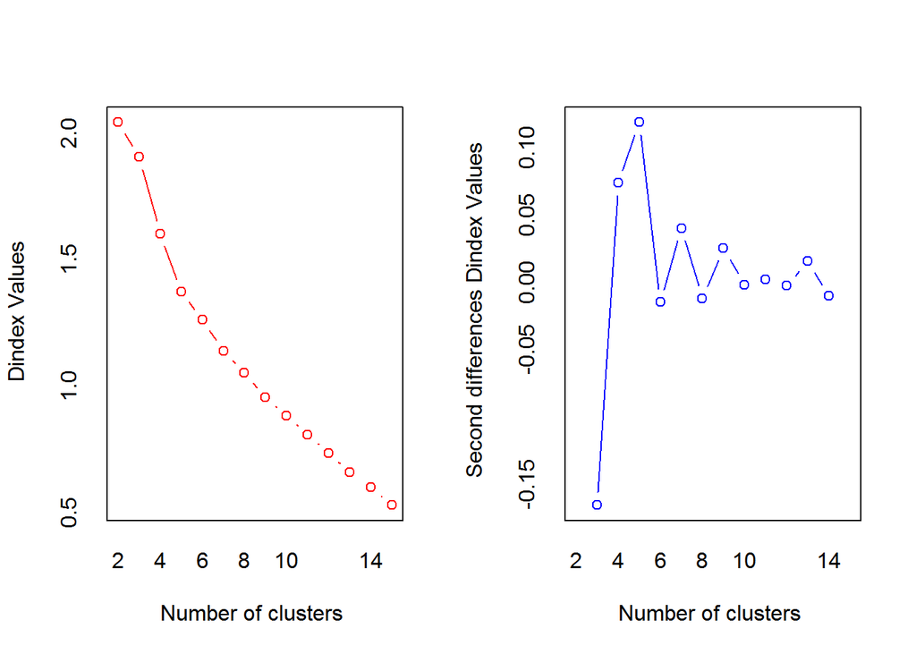

```
## *** : The D index is a graphical method of determining the number of clusters.
##                 In the plot of D index, we seek a significant knee (the significant peak in Dindex
##                 second differences plot) that corresponds to a significant increase of the value of
##                 the measure.
##
## * Among all indices:
## * 9 proposed 2 as the best number of clusters
## * 6 proposed 3 as the best number of clusters
## * 1 proposed 4 as the best number of clusters
## * 3 proposed 5 as the best number of clusters
## * 1 proposed 6 as the best number of clusters
## * 1 proposed 10 as the best number of clusters
## * 2 proposed 14 as the best number of clusters
## * 1 proposed 15 as the best number of clusters
##
##                    ***** Conclusion *****
##
## * According to the majority rule, the best number of clusters is  2
##
##
```

```r
table(tenc$Best.n[1,])
```

```
##
##  0  2  3  4  5  6 10 14 15
##  2  9  6  1  3  1  1  2  1
```

```r
barplot(table(tenc$Best.n[1,]),
        xlab="Number of Clusters", ylab="Number of Criteria",
        main="Number of Clusters Chosen")

teclusters <- cutree(fit.average, k=3)
table(teclusters)
```

```
## teclusters
##  1  2  3
##  1 23  1
```

```r
aggregate(te[,-1], by=list(cluster=teclusters), median)
```

```
##   cluster Targets_Per_Game Reception_Percent Reception_TD_Per_Game
## 1       1         4.750000         0.6578947             0.3750000
## 2       2         5.937500         0.6842105             0.3125000
## 3       3         4.090909         0.5333333             0.3636364
##   Yards_Per_Target Yards_Per_Reception Fantasy_PPG
## 1        14.210526            21.60000    9.000000
## 2         7.786667            11.57895    6.771429
## 3         8.688889            16.29167    5.736364
```

```r
aggregate(as.data.frame(te.scaled), by=list(cluster=teclusters),
          median)
```

```
##   cluster Targets_Per_Game Reception_Percent Reception_TD_Per_Game
## 1       1      -0.79982820        -0.3092579             0.2636609
## 2       2       0.05112832         0.1087428            -0.1468772
## 3       3      -1.27212943        -2.2877945             0.1890176
##   Yards_Per_Target Yards_Per_Reception Fantasy_PPG
## 1        3.5537397           3.5656856  1.61561555
## 2       -0.2099682          -0.1925517  0.04064647
## 3        0.3186394           1.5748792 -0.69085141
```

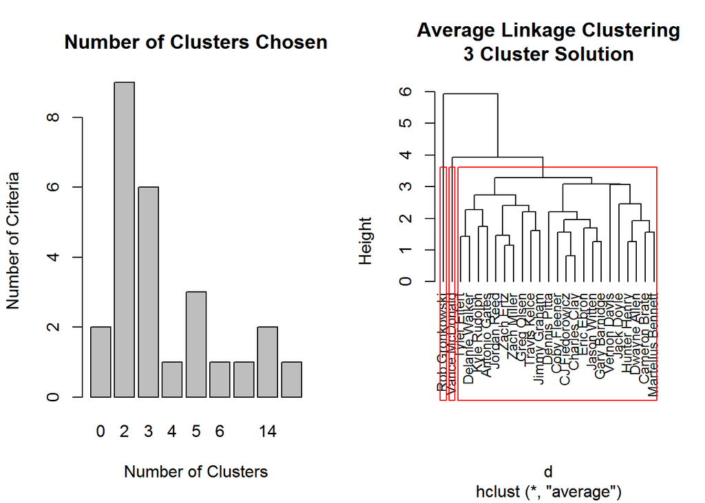

```r
plot(fit.average, hang=-1, cex=.8,
     main="Average Linkage Clustering\n3 Cluster Solution")
rect.hclust(fit.average, k=3)
```

#### Hierarchical Clustering Results by Position (Ward Method)

##### QB

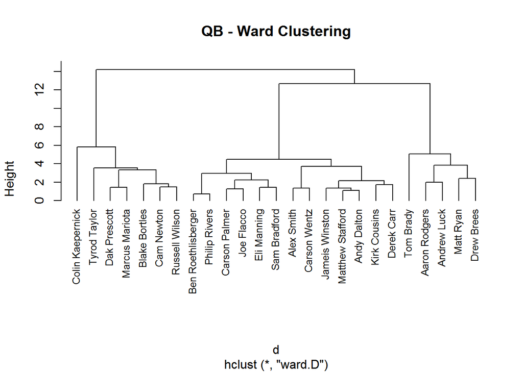

```r
data(qb, package="flexclust")
row.names(qb) <- qb[,1]
qb.scaled <- scale(qb[,-1])
d <- dist(qb.scaled)
fit.average <- hclust(d, method="ward.D")
plot(fit.average, hang=-1, cex=.8, main="QB - Ward Clustering")
```

```r
devAskNewPage(ask=TRUE)
qbnc <- NbClust(qb.scaled, distance="euclidean", min.nc=2, max.nc=15, method="ward.D")
```

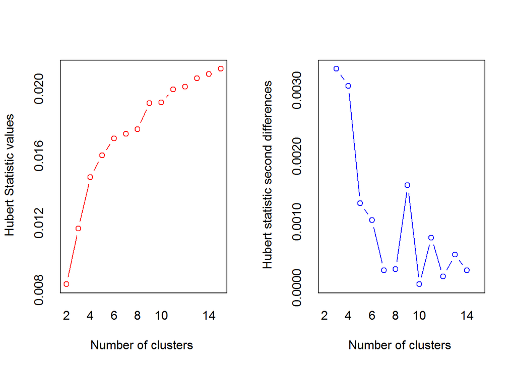

```
## *** : The Hubert index is a graphical method of determining the number of clusters.
##                 In the plot of Hubert index, we seek a significant knee that corresponds to a
##                 significant increase of the value of the measure i.e the significant peak in Hubert
##                 index second differences plot.
##
```

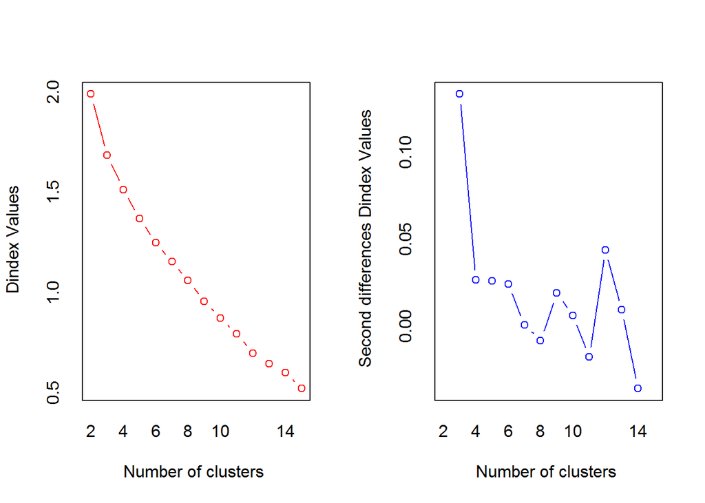

```
## *** : The D index is a graphical method of determining the number of clusters.
##                 In the plot of D index, we seek a significant knee (the significant peak in Dindex
##                 second differences plot) that corresponds to a significant increase of the value of
##                 the measure.
##
## * Among all indices:
## * 3 proposed 2 as the best number of clusters
## * 11 proposed 3 as the best number of clusters
## * 4 proposed 5 as the best number of clusters
## * 5 proposed 15 as the best number of clusters
##
##                    ***** Conclusion *****
##
## * According to the majority rule, the best number of clusters is  3
##
##
```

```r
table(qbnc$Best.n[1,])
```

```
##
##  0  1  2  3  5 15
##  2  1  3 11  4  5
```

```r
barplot(table(qbnc$Best.n[1,]),
        xlab="Number of Clusters", ylab="Number of Criteria",
        main="Number of Clusters Chosen")

qbclusters <- cutree(fit.average, k=3)
table(qbclusters)
```

```
## qbclusters
##  1  2  3
##  5 13  7
```

```r
aggregate(qb[,-1], by=list(cluster=qbclusters), median)
```

```
##   cluster Pass_Attempts_Per_Game Pass_Yards_Per_Game Pass_TD_Per_Game
## 1       1               36.33333            296.1667         2.333333
## 2       2               37.12500            262.8750         1.562500
## 3       3               30.06667            229.1875         1.312500
##   Pass_TD_Int_Ratio Rush_Yards_Per_Game Rush_Attempts_Per_Game Fantasy_PPG
## 1          5.428571             7.31250               2.333333    21.54667
## 2          1.875000             4.60000               2.125000    16.18375
## 3          2.833333            23.26667               4.312500    16.95067
```

```r
aggregate(as.data.frame(qb.scaled), by=list(cluster=qbclusters),
          median)
```

```
##   cluster Pass_Attempts_Per_Game Pass_Yards_Per_Game Pass_TD_Per_Game
## 1       1              0.2375643           1.0061747        1.5081903
## 2       2              0.4115360           0.1265221       -0.1405017
## 3       3             -1.1395594          -0.7635894       -0.6752125
##   Pass_TD_Int_Ratio Rush_Yards_Per_Game Rush_Attempts_Per_Game Fantasy_PPG
## 1         0.8553556          -0.4796195             -0.3840228   1.5329301
## 2        -0.4788856          -0.7415154             -0.5222287  -0.4081603
## 3        -0.1190651           1.0607790              0.9289330  -0.1305773
```

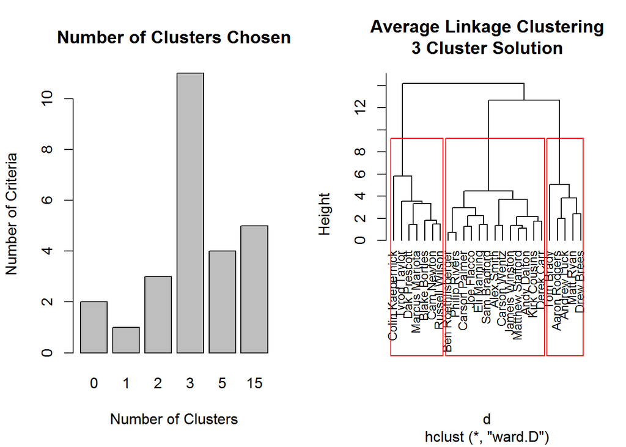

```r
plot(fit.average, hang=-1, cex=.8,
     main="Average Linkage Clustering\n3 Cluster Solution")
rect.hclust(fit.average, k=3)
```

##### RB

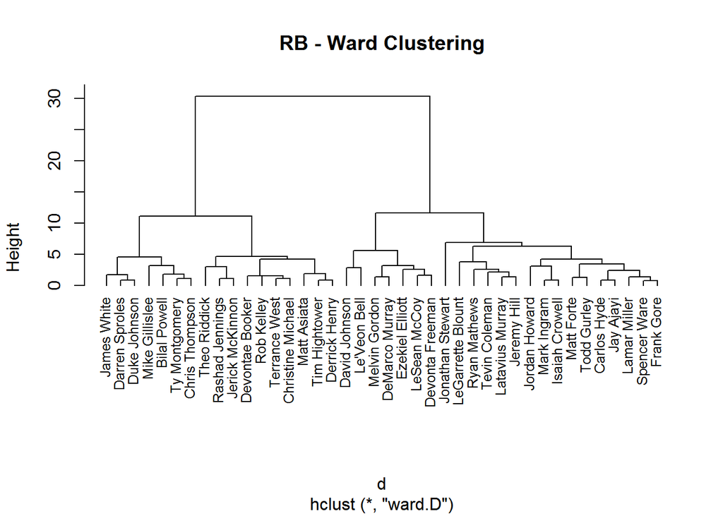

```r
data(rb, package="flexclust")
row.names(rb) <- rb[,1]
rb.scaled <- scale(rb[,-1])
d <- dist(rb.scaled)
fit.average <- hclust(d, method="ward.D")
plot(fit.average, hang=-1, cex=.8, main="RB - Ward Clustering")
```

```r
devAskNewPage(ask=TRUE)
rbnc <- NbClust(rb.scaled, distance="euclidean", min.nc=2, max.nc=15, method="ward.D")
```

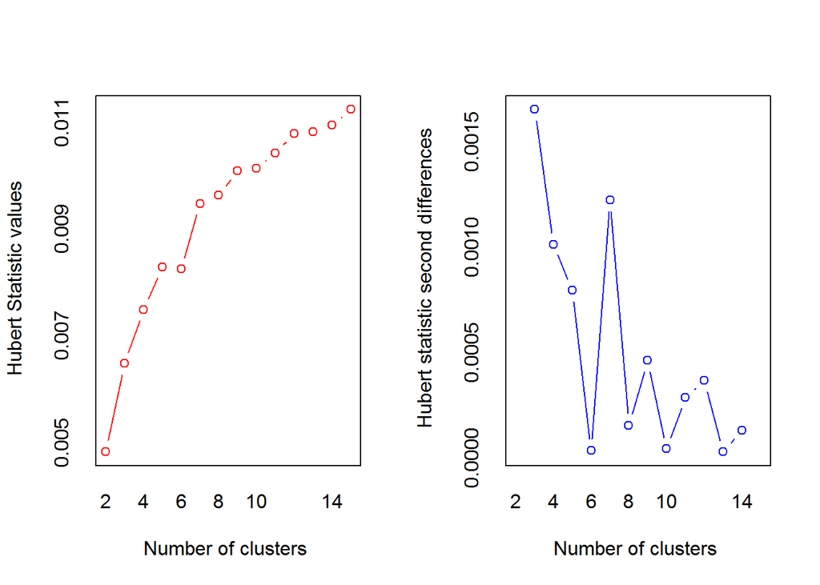

```
## *** : The Hubert index is a graphical method of determining the number of clusters.
##                 In the plot of Hubert index, we seek a significant knee that corresponds to a
##                 significant increase of the value of the measure i.e the significant peak in Hubert
##                 index second differences plot.
##
```

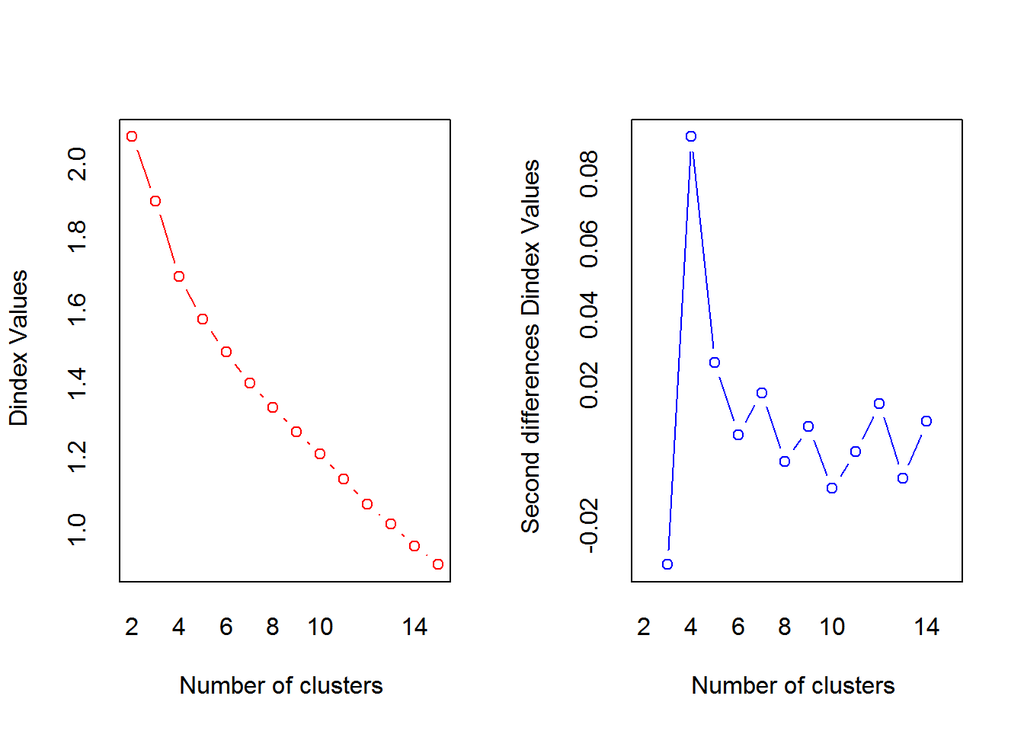

```
## *** : The D index is a graphical method of determining the number of clusters.
##                 In the plot of D index, we seek a significant knee (the significant peak in Dindex
##                 second differences plot) that corresponds to a significant increase of the value of
##                 the measure.
##
## * Among all indices:
## * 7 proposed 2 as the best number of clusters
## * 4 proposed 3 as the best number of clusters
## * 5 proposed 4 as the best number of clusters
## * 2 proposed 5 as the best number of clusters
## * 1 proposed 7 as the best number of clusters
## * 1 proposed 12 as the best number of clusters
## * 3 proposed 15 as the best number of clusters
##
##                    ***** Conclusion *****
##
## * According to the majority rule, the best number of clusters is  2
##
##
```

```r
table(rbnc$Best.n[1,])
```

```
##
##  0  1  2  3  4  5  7 12 15
##  2  1  7  4  5  2  1  1  3
```

```r
barplot(table(rbnc$Best.n[1,]),
        xlab="Number of Clusters", ylab="Number of Criteria",
        main="Number of Clusters Chosen")

rbclusters <- cutree(fit.average, k=4)
table(rbclusters)
```

```
## rbclusters
##  1  2  3  4
##  7 16 10  7
```

```r
aggregate(rb[,-1], by=list(cluster=rbclusters), median)
```

```
##   cluster Rush_Yards_Per_Game Rush_Attempts_Per_Game
## 1       1            80.43750              18.312500
## 2       2            63.75481              15.660714
## 3       3            37.09167              10.183333
## 4       4            29.20000               5.133333
##   Rush_Yards_Per_Attempt Rush_TD_Per_Game Touches_Per_Game
## 1               4.753304        0.7692308         22.12500
## 2               4.152771        0.4807692         17.60268
## 3               3.909812        0.2812500         12.07292
## 4               5.235294        0.1875000          7.87500
##   Targets_Per_Game Reception_Percent Fantasy_PPG
## 1          4.18750         0.7978723   16.553333
## 2          2.96875         0.7763889   11.464286
## 3          2.59375         0.8011828    7.282083
## 4          4.62500         0.7837838    6.433333
```

```r
aggregate(as.data.frame(rb.scaled), by=list(cluster=rbclusters),
          median)
```

```
##   cluster Rush_Yards_Per_Game Rush_Attempts_Per_Game
## 1       1           1.1248609              1.1137328
## 2       2           0.3903342              0.5848441
## 3       3          -0.7836244             -0.5075989
## 4       4          -1.1310887             -1.5148024
##   Rush_Yards_Per_Attempt Rush_TD_Per_Game Touches_Per_Game
## 1              0.5585264        1.1899340        1.3184532
## 2             -0.3151380        0.1229906        0.4551473
## 3             -0.6685981       -0.6149786       -0.6004778
## 4              1.2597327       -0.9617352       -1.4018552
##   Targets_Per_Game Reception_Percent Fantasy_PPG
## 1        0.5563623        0.33112332    1.479670
## 2       -0.1801992        0.09594881    0.182498
## 3       -0.4068335        0.36736180   -0.883524
## 4        0.8207690        0.17689906   -1.099866
```

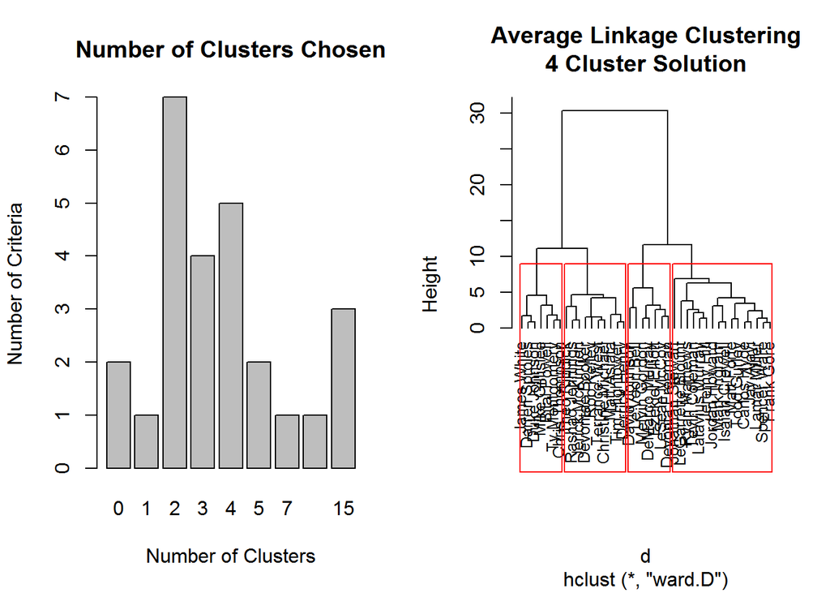

```r
plot(fit.average, hang=-1, cex=.8,
     main="Average Linkage Clustering\n4 Cluster Solution")
rect.hclust(fit.average, k=4)
```

##### WR

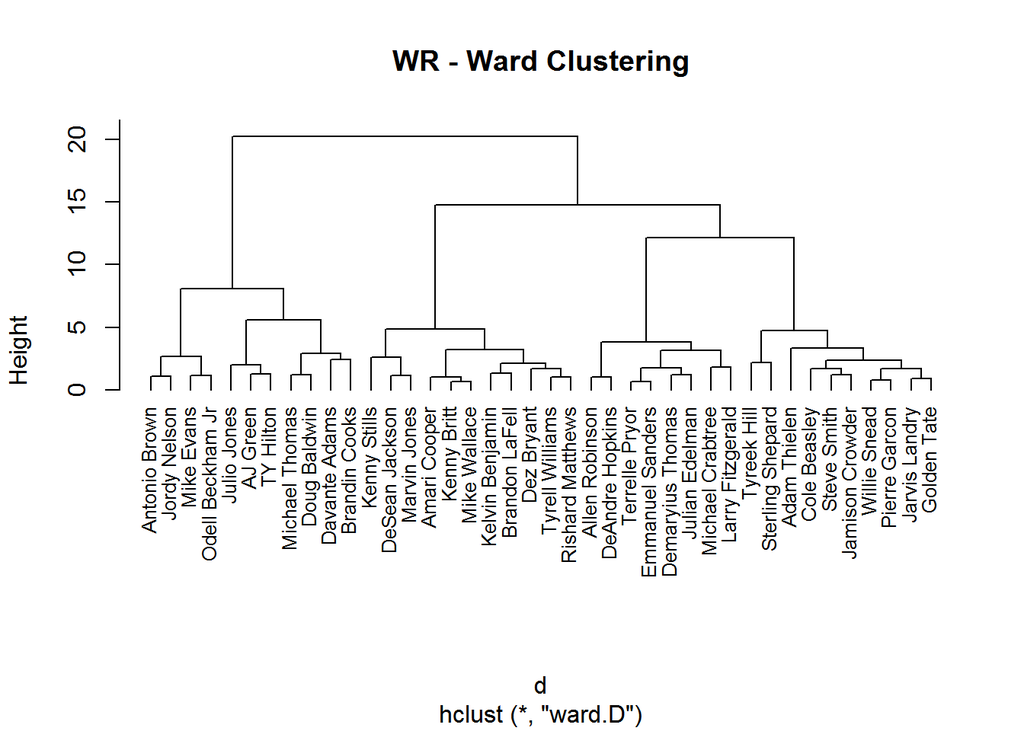

```r
data(wr, package="flexclust")
row.names(wr) <- wr[,1]
wr.scaled <- scale(wr[,-1])
d <- dist(wr.scaled)
fit.average <- hclust(d, method="ward.D")
plot(fit.average, hang=-1, cex=.8, main="WR - Ward Clustering")
```

```r
devAskNewPage(ask=TRUE)
wrnc <- NbClust(wr.scaled, distance="euclidean", min.nc=2, max.nc=15, method="ward.D")
```

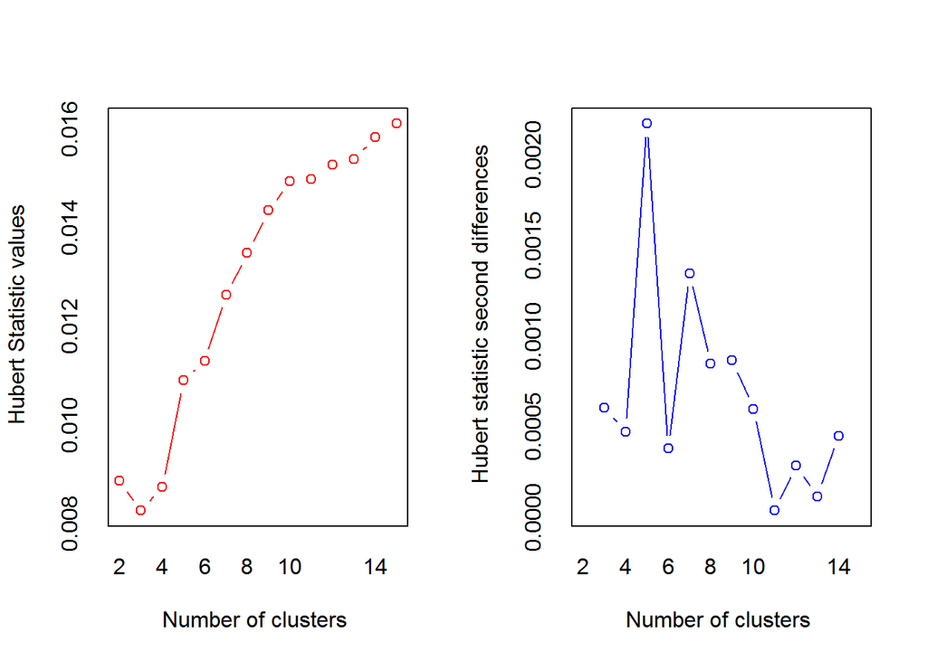

```
## *** : The Hubert index is a graphical method of determining the number of clusters.
##                 In the plot of Hubert index, we seek a significant knee that corresponds to a
##                 significant increase of the value of the measure i.e the significant peak in Hubert
##                 index second differences plot.
##
```

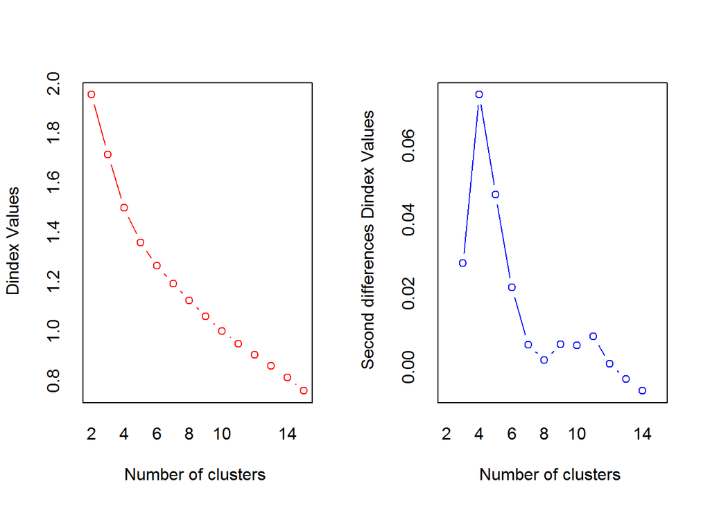

```
## *** : The D index is a graphical method of determining the number of clusters.
##                 In the plot of D index, we seek a significant knee (the significant peak in Dindex
##                 second differences plot) that corresponds to a significant increase of the value of
##                 the measure.
##
## * Among all indices:
## * 4 proposed 2 as the best number of clusters
## * 2 proposed 3 as the best number of clusters
## * 3 proposed 4 as the best number of clusters
## * 1 proposed 5 as the best number of clusters
## * 2 proposed 6 as the best number of clusters
## * 4 proposed 7 as the best number of clusters
## * 3 proposed 8 as the best number of clusters
## * 1 proposed 13 as the best number of clusters
## * 3 proposed 15 as the best number of clusters
##
##                    ***** Conclusion *****
##
## * According to the majority rule, the best number of clusters is  2
##
##
```

```r
table(wrnc$Best.n[1,])
```

```
##
##  0  1  2  3  4  5  6  7  8 13 15
##  2  1  4  2  3  1  2  4  3  1  3
```

```r
barplot(table(wrnc$Best.n[1,]),
        xlab="Number of Clusters", ylab="Number of Criteria",
        main="Number of Clusters Chosen")

wrclusters <- cutree(fit.average, k=4)
table(wrclusters)
```

```
## wrclusters
##  1  2  3  4
## 11 11  8 10
```

```r
aggregate(wr[,-1], by=list(cluster=wrclusters), median)
```

```
##   cluster Targets_Per_Game Reception_Percent Reception_TD_Per_Game
## 1       1         9.500000         0.6434109                0.6000
## 2       2         7.250000         0.5798319                0.3750
## 3       3         9.218750         0.5952177                0.3125
## 4       4         6.747917         0.6930259                0.3125
##   Yards_Per_Target Yards_Per_Reception Fantasy_PPG
## 1         9.024000            13.53465   12.040000
## 2         8.770992            14.93651    8.381250
## 3         6.936608            12.06461    8.434375
## 4         8.527778            11.96014    7.927083
```

```r
aggregate(as.data.frame(wr.scaled), by=list(cluster=wrclusters),
          median)
```

```
##   cluster Targets_Per_Game Reception_Percent Reception_TD_Per_Game
## 1       1        1.0290476         0.1844117             1.0542274
## 2       2       -0.4926666        -0.6673584            -0.2584397
## 3       3        0.8388333        -0.4612343            -0.6230694
## 4       4       -0.8322343         0.8491068            -0.6230694
##   Yards_Per_Target Yards_Per_Reception Fantasy_PPG
## 1        0.5951467          0.07500951   1.5596256
## 2        0.3707396          0.76935142  -0.4995781
## 3       -1.2562824         -0.65310564  -0.4696785
## 4        0.1550184         -0.70485299  -0.7551904
```

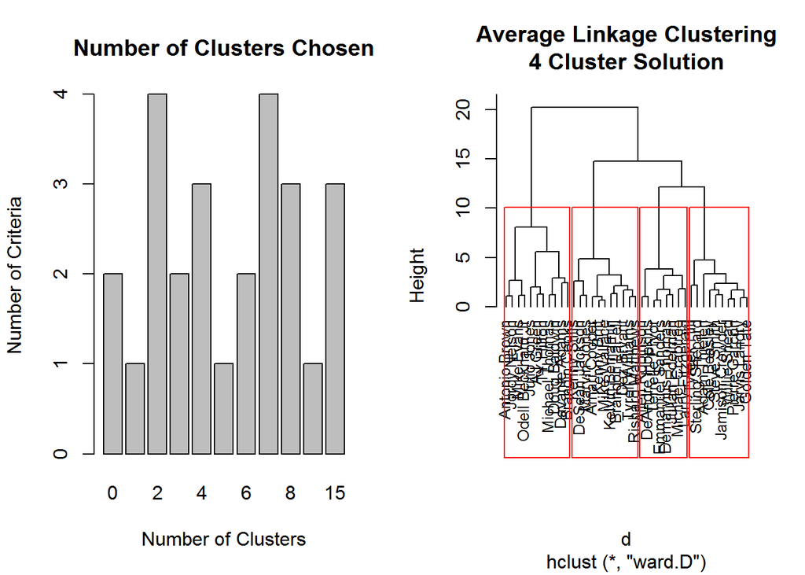

```r
plot(fit.average, hang=-1, cex=.8,
     main="Average Linkage Clustering\n4 Cluster Solution")
rect.hclust(fit.average, k=4)
```

##### TE

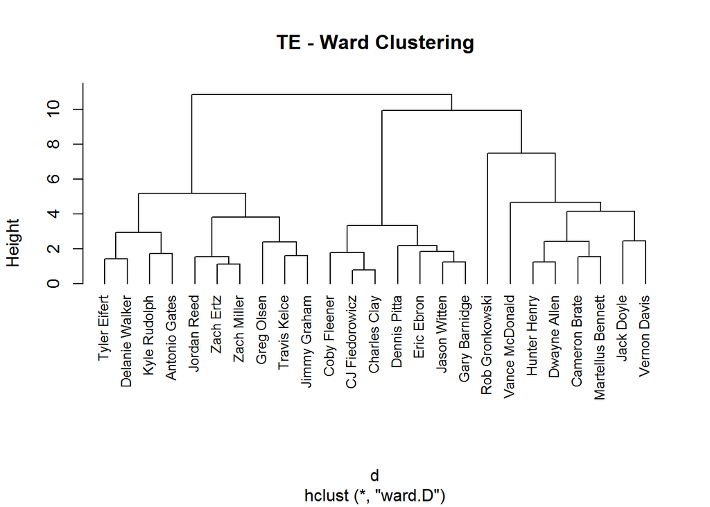

```r
data(te, package="flexclust")
row.names(te) <- te[,1]
te.scaled <- scale(te[,-1])
d <- dist(te.scaled)
fit.average <- hclust(d, method="ward.D")
plot(fit.average, hang=-1, cex=.8, main="TE - Ward Clustering")
```

```r
devAskNewPage(ask=TRUE)
tenc <- NbClust(te.scaled, distance="euclidean", min.nc=2, max.nc=15, method="ward.D")
```

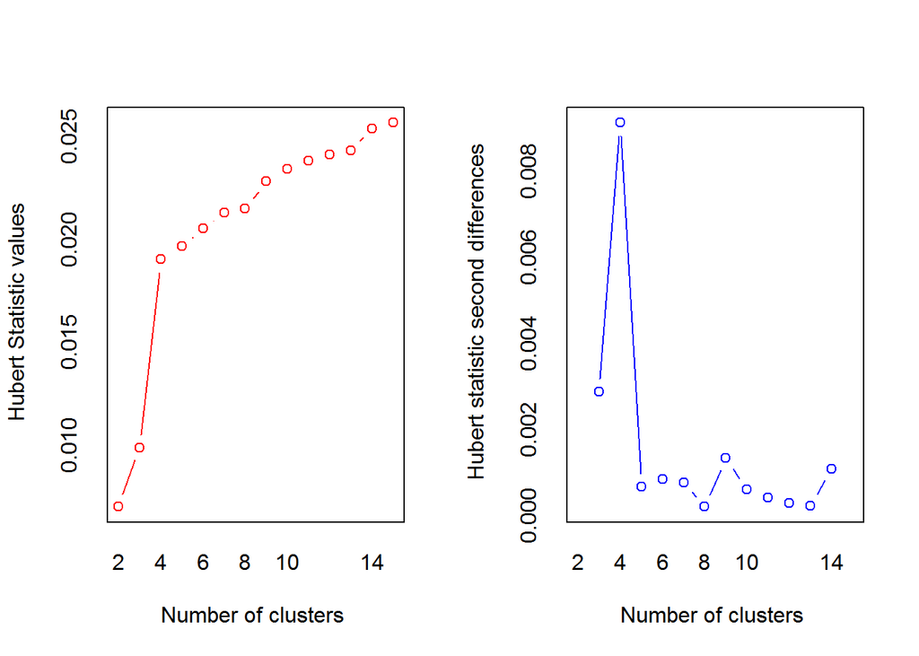

```
## *** : The Hubert index is a graphical method of determining the number of clusters.
##                 In the plot of Hubert index, we seek a significant knee that corresponds to a
##                 significant increase of the value of the measure i.e the significant peak in Hubert
##                 index second differences plot.
##
```

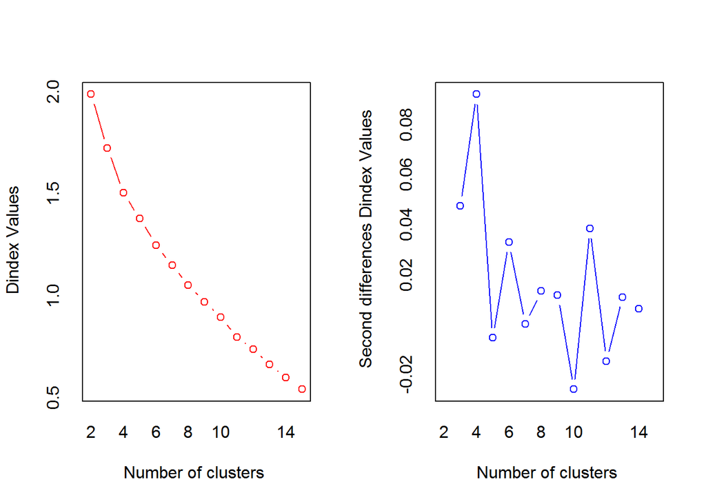

```
## *** : The D index is a graphical method of determining the number of clusters.
##                 In the plot of D index, we seek a significant knee (the significant peak in Dindex
##                 second differences plot) that corresponds to a significant increase of the value of
##                 the measure.
##
## * Among all indices:
## * 4 proposed 2 as the best number of clusters
## * 3 proposed 3 as the best number of clusters
## * 7 proposed 4 as the best number of clusters
## * 1 proposed 6 as the best number of clusters
## * 2 proposed 7 as the best number of clusters
## * 1 proposed 11 as the best number of clusters
## * 1 proposed 14 as the best number of clusters
## * 4 proposed 15 as the best number of clusters
##
##                    ***** Conclusion *****
##
## * According to the majority rule, the best number of clusters is  4
##
##
```

```r
table(tenc$Best.n[1,])
```

```
##
##  0  1  2  3  4  6  7 11 14 15
##  2  1  4  3  7  1  2  1  1  4
```

```r
barplot(table(tenc$Best.n[1,]),
        xlab="Number of Clusters", ylab="Number of Criteria",
        main="Number of Clusters Chosen")

teclusters <- cutree(fit.average, k=4)
table(teclusters)
```

```
## teclusters
##  1  2  3  4
##  1 10  7  7
```

```r
aggregate(te[,-1], by=list(cluster=teclusters), median)
```

```
##   cluster Targets_Per_Game Reception_Percent Reception_TD_Per_Game
## 1       1         4.750000         0.6578947             0.3750000
## 2       2         7.056250         0.6607327             0.4187500
## 3       3         4.090909         0.7037037             0.4285714
## 4       4         5.933333         0.6790123             0.1875000
##   Yards_Per_Target Yards_Per_Reception Fantasy_PPG
## 1        14.210526            21.60000    9.000000
## 2         7.775501            11.38462    7.915625
## 3         8.688889            12.74545    5.736364
## 4         7.084211            10.35185    5.280000
```

```r
aggregate(as.data.frame(te.scaled), by=list(cluster=teclusters),
          median)
```

```
##   cluster Targets_Per_Game Reception_Percent Reception_TD_Per_Game
## 1       1      -0.79982820       -0.30925791             0.2636609
## 2       2       0.85281894       -0.26417941             0.5510376
## 3       3      -1.27212943        0.41837291             0.6155507
## 4       4       0.04814251        0.02617474            -0.9679535
##   Yards_Per_Target Yards_Per_Reception Fantasy_PPG
## 1        3.5537397           3.5656856   1.6156155
## 2       -0.2165100          -0.2654328   0.8492694
## 3        0.3186394           0.2449284  -0.6908514
## 4       -0.6215338          -0.6527544  -1.0133713
```

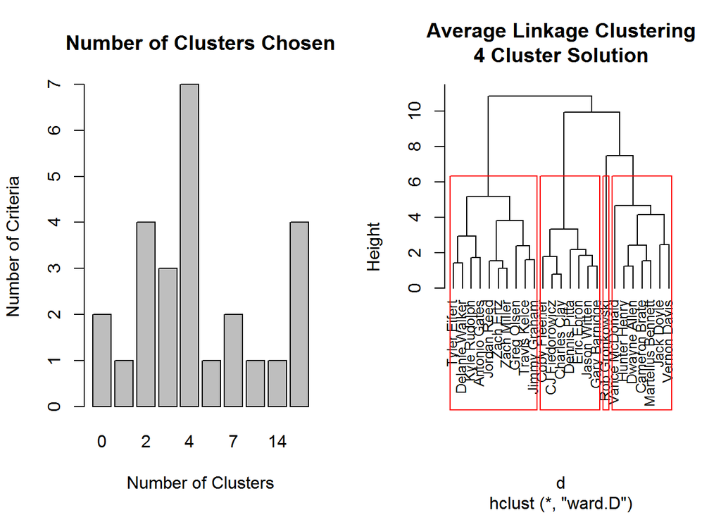

```r
plot(fit.average, hang=-1, cex=.8,
     main="Average Linkage Clustering\n4 Cluster Solution")
rect.hclust(fit.average, k=4)
```